# Assignment 1

## 1.2 Principal Component Analysis

**1.2.1** many experimenters have a habit of using Microsoft Excel as their tool to record measurements from experiments. Fortunately Python can read Excel files. Various methods exist, of which the use of the Python library Pandas is arguably one of the easiest for the purpose of Data Mining.

> a. (0.2 points) Inspect the nanonose.xls file in the Data folder and make sure you understand how the data is stored in Excel.

> *Load the data in python using the Pandas library (use the `read_excel()` function). Make sure you read some of the Pandas documentation! Especially (column) slicing, (row) indexing and dropping are useful commands to get the correct data here.*

> *Make sure to inspect the data first. **You should cut out some rows and columns! You can easily inspect the structure of the Pandas dataframe by printing the `head()` function.***

> *You should see the 8 columns named A-H and the first 5 rows by printing `head()`.*

> *Finally use the `.values` function to cast the Pandas dataframe to a NumPy array called **X**.*

```python
import pandas as pd

data = pd.read_excel('C:\\Users\\quiri\\OneDrive\\RU\\Data Mining\\Assignment_1\\data\\nanonose.xls')
data = (data[data.columns[2:]])
print(data.head())
X = np.array(data.values)
# print(X)
```

```
      A     B    C          D          E          F         G         H
0  95.5  21.0  6.0  11.942308  64.134615  21.498560  5.567840  1.174135
1  94.5  17.0  5.0   5.484615  63.205769  19.658560  4.968000  1.883444
2  92.0  16.0  3.0  11.057692  62.586538  19.813120  5.192480  0.564835
3  53.0   7.5  2.5   3.538462  35.163462   6.876207  1.641724  0.144654
4  51.0   7.5  2.5   4.865385  34.057692   6.757241  1.613966  0.059663
```

> b. (0.3 points) The data resides in what can be seen as an 8-dimensional space. Each dimension (column), corresponds to one of the 8 NanoNose sensors. Multidimensional (>3) data is hard to visualize, as we are unable to plot that many dimensions simultaneously.

> Using the `matplotlib.pyplot` library, plot the attributes A and B against each other. After you have plotted A against B, also plot a few other combinations of attributes. Plot at least 4 different combinations.

> *Do not forget to label your axes and add a figure description!*

> NOTE: If you want to plot inside the Jupyter notebook without calling `plt.show()` after each plot, use the following command after you imported the `matplotlib.pyplot` library: *%matplotlib inline*

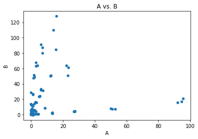

```
Attributes A and B plotted against each other
```

```python
import matplotlib.pyplot as plt
%matplotlib inline

data.plot(kind = 'scatter', x = "A", y = "B")
# plt.plot(X[:,2], X[:,3])
plt.xlabel("A")
plt.ylabel("B")
plt.title("A vs. B")
plt.show()
print('Attributes A and B plotted against each other')
```

1.2.2 Principal Component Analysis, more commonly known as PCA, can be used to visualize high dimensional data.

> a. (1 point) Explain what PCA is and when it can be used. Make sure to provide an in-depth explanation and note what the drawbacks and limitations are.

*write your answer to 1.2.2 here*

------- A PCA plot converts the correlations among all the different variables in a 2D graph (There are too many columns to plot against achother, so you make a PCA plot to still make sense of all data and find correlations between the data). Drawbacks: -PCA assumes all data is linear: if this is not the case, PCA won't work. -It treats high variance as most important, and low variance as noise. However, you don't want to look at the high variance all the time, but is overshadows the low variance. -PCA assume that the principle components are orthogonal.

To apply PCA we must first mean center the data. Mean centering means that the mean value for an attribute (i.e. a column) is subtracted from all values for that attribute.

> b. (0.5 points) Why do we first need to mean center the data before applying PCA?

*write your answer to 1.2.2 here*

PCA has no real structure in itself, so if you would plot the data, you don't really know where to look at. When you standardize by mean centering the data, you give direction to the data, because it shows the variability of samples across the mean.

In practice, applying PCA comes down to a series of matrix operations, this is useful, as matrix operations can be applied with little effort and can be computed in relatively little time.

The given data **X** must first be mean centered. This can be easily done by calculating a row vector **μ** containing the mean values of each attribute. Then you can subtract **μ** from **X** (**Y** = **X** - **μ**, where **μ** is subtracted from every row.).

Then, the Singular Value Decomposition (or SVD) of **Y**, the now mean centered data, can be calculated. **Y** = **USV**<sup>T</sup>. In practice, this is often done using the `numpy.linalg.svd()` function.

Using SVD on **Y** yields 3 matrices **U**, **S** and **V**<sup>T</sup>. These are used to project the data onto specific Principal Components (PCs).

The entire dataset can be projected onto the Principal Components by multiplying **Z** = **Y*V**, where **Z** indicates the projected data, and **Z[:,0]** indicates the data projected onto the first PC. Alternatively, one could project onto just a subset of all the PCs by indexing in the multiplication. For example: **Z** = **Y*V[:,0]** would also yield the projection of the data onto the first PC.

*Note that for matrices, the notation **Y*V** denotes the `dot` product between **Y** and **V**!*

> c. (1 point) Apply PCA (using the aforementioned method) on the Nanonose data and visualize a scatterplot of the projection of the data onto the first two PCs.

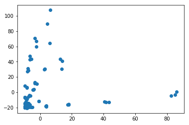

```python
mu = X.mean(axis=0)
# print(mu)
Y = X - mu
# print(Y)
plt.scatter(Y[:,0],Y[:,1])
plt.show()
```

> d. (1 point) Alternatively, one could use EigenValue Decomposition, EVD, instead of SVD. What are the similarities and differences between SVD and EVD? Can both be applied in each case?

_write your answer to 1.2.2 The Sum of Squared distances of the line (PC) that fits over the data best (and goes to the origin) is the eigenvalue. The Singular Value for PC1 is the square root of the Eigenvalue for PC1. So both can be used in each case, because they are so strongly connected.

PCA attempts to explain as much of the variance in data with as few PCs as possible. The variance explained by each of the PCs **m** can be calculated using the following formula: $$\rho_m = 1 - \frac{\|{Y} - {u}_m s_{mm} {v}_m^T\|^2_F}{\|{Y}\|^2_F} = \frac{s_{mm}^2}{\displaystyle \sum_{m'=1}^M s^2_{m'm'}}$$ Which indicates that the variation $\rho$ for a given **m** can be calculated by dividing the squared singular value of component **m** by the sum of all squared singular values. > e. (1 point) Calculate the row vector $\rho$ containing all values of $\rho$ for all PCs **m**. Create a bar plot with the variance explained on the Y axis and the number of the PC on the X axis.

```python
U, Sv, Vt = np.linalg.svd(X)
rho = (Sv*Sv) / sum (Sv*Sv)
amountPCs = len(X[0])

PCs = np.array()
for i in range(amountPCs):
    PCs = np.append(PCs, i+1)

plt.bar(PCs, rho)
pt.xlabel('PCs')
plt.ylabel('Varience percentage')
plt.title('Varience percentage per PC')
```

[output not shown]

> f. (0.5 points) How much of the variance is explained by the first three PCs?

```python
# The first 3 PCs explaine almost all of the variance.
# After that the variences become really small (which in some cases can be usefull as wel).
# So the largest variences are explained in the first three PCs
```

[output not shown]

The columns of **V** indicate the exact projection of the data onto the PCs. In a way, a PC is nothing other than a linear combination of the original attributes.

> g. (0.5 points) Which attributes are primarily represented by the first PC? What would cause an observation to have a large negative/positive projection onto the second principal component?

```python
# PC1 is build up by the sum of the squared distance of the line that fits the data best and goes through the origin.
#
```

*write your answer to 1.2.2 here*

## 1.3 Similarity measures

We will use a subset of the data on wild faces described by Berg in 2005 transformed to a total of 1000 grayscale images of size 40x40 pixels, we will attempt to find faces in the data base that are the most similar to a given query face. To measure similarity we will consider the following measures: SMC, Jaccard, Cosine, ExtendedJaccard, and Correlation. These measures of similarity are described in *Introduction to Data Mining*, page 73-77 and are given by

\begin{eqnarray*} \textrm{SMC}({x},{y}) & = & \frac{\textrm{Number of matching attribute values}}{\textrm{Number of attributes}} \\ \textrm{Jaccard}({x},{y}) & = & \frac{\textrm{Number of matching presences}}{\textrm{Number of attributes not involved in 00 matches}} \\ \textrm{Cosine}({x},{y}) & = & \frac{{x}^T {y}}{\|{x}\| \|{y}\|} \\ \textrm{ExtendedJaccard}({x},{y}) & = & \frac{{x}^T {y}}{\|{x}\|^2 + \|{y}\|^2 - {x}^T {y}} \\ \textrm{Correlation}({x},{y}) & = & \frac{\textrm{cov}({x},{y})}{\textrm{std}({x}) \textrm{std}({y})} \\ \end{eqnarray*}  
where $\textrm{cov}({x},{y})$ denotes the covariance between ${x}$ and ${y}$ and $\textrm{std}({x})$ denotes the standard deviation of ${x}$.

Notice that the SMC and Jaccard similarity measures only are defined for binary data, i.e., data that takes values in $\{0,1\}$. As the data we analyze is non-binary, the script will transform the data to be binary when calculating these two measures of similarity by setting

$$x_i = \left\{ \begin{array}{ll} 0 & \textrm{if~} x_i < \textrm{median}({x}) \\ 1 & \textrm{otherwise.} \end{array} \right.$$

### 1.3.1

> a) (0.5 points) Inspect and run the simfaces function from the Toolbox. The function loads the CBCL face database, computes the similarity between a selected query image and all others, and display the query image, the 5 most similar images, and the 5 least similar images. The value of the used similarity measure is shown below each image. Try changing the query image and the similarity measure and see what happens. Which similarity measures produce similar results? Which one gives the best result? Why?

> Give a quick overview of the settings (image number and similarity measure) for each time you run the script. Remember to leave results open!

```python
def simfaces(i=1, similarity_measure = 'smc'):
	# i is the Image to use as query

	# Similarity: 'SMC', 'Jaccard', 'ExtendedJaccard', 'Cosine', 'Correlation'


	# Load the CBCL face database
	# Load Matlab data file to python dict structure
    #str(pathlib.Path.cwd().joinpath("Data","wildfaces_grayscale.mat"))
	X = loadmat("Data/wildfaces_grayscale.mat")['X']
	N, M = shape(X)


	# Search the face database for similar faces
	# Index of all other images than i
	noti = list(range(0,i)) + list(range(i+1,N))
	# Compute similarity between image i and all others
	sim = similarity(X[i,:], X[noti,:], similarity_measure)
	sim = sim.tolist()[0]
	# Tuples of sorted similarities and their indices
	sim_to_index = sorted(zip(sim,noti))


	# Visualize query image and 5 most/least similar images
	figure(figsize=(12,8))
	subplot(3,1,1)
	imshow(np.reshape(X[i],(40,40)).T, cmap=cm.gray)
	xticks([]); yticks([])
	title('Query image')
	ylabel('image #{0}'.format(i))


	for ms in range(5):

		# 5 most similar images found
		subplot(3,5,6+ms)
		im_id = sim_to_index[-ms-1][1]
		im_sim = sim_to_index[-ms-1][0]
		imshow(np.reshape(X[im_id],(40,40)).T, cmap=cm.gray)
		xlabel('sim={0:.3f}'.format(im_sim))
		ylabel('image #{0}'.format(im_id))
		xticks([]); yticks([])
		if ms==2: title('Most similar images')

		# 5 least similar images found
		subplot(3,5,11+ms)
		im_id = sim_to_index[ms][1]
		im_sim = sim_to_index[ms][0]
		imshow(np.reshape(X[im_id],(40,40)).T, cmap=cm.gray)
		xlabel('sim={0:.3f}'.format(im_sim))
		ylabel('image #{0}'.format(im_id))
		xticks([]); yticks([])
		if ms==2: title('Least similar images')

	show()
```

*write your answer to 1.3.1 here*

> b) (0.75 points) We will investigate how scaling and translation impact the following three similarity measures: Cosine, ExtendedJaccard, and Correlation. Let **x** and **y** be two small vectors of the same size. Let $\alpha$ and $\beta$ be two constants. You can generate these randomly or set them as you see fit. Using Python, calculate the following similarity measures, and check if the statements below are correct.

\begin{eqnarray*} \textrm{Cosine}(\alpha{x},{y}) & = & \textrm{Cosine}({x},{y}) \\ \textrm{ExtendedJaccard}(\alpha{x},{y}) & = & \textrm{ExtendedJaccard}({x},{y}) \\ \textrm{Correlation}(\alpha{x},{y}) & = & \textrm{Correlation}({x},{y}) \\ \textrm{Cosine}(\beta + {x},{y}) & = & \textrm{Cosine}({x},{y}) \\ \textrm{ExtendedJaccard}(\beta + {x},{y}) & = & \textrm{ExtendedJaccard}({x},{y}) \\ \textrm{Correlation}(\beta + {x},{y}) & = & \textrm{Correlation}({x},{y}) \end{eqnarray*}

> Type `help similarity` or study `similarity.py` to learn about the function that is used to compute the similarity measures. Do not forget to also import similarity.py!

> Even though a similarity measure is theoretically invariant e.g.\ to scaling, it might not be exactly invariant numerically.

> Do not forget to also provide an explanation in addition to the calculations!

*write your answer to 1.3.1 here*